[Home](https://adamdennett.github.io/school_attainment_tool/) [GitHub](https://github.com/adamdennett/school_attainment_tool)

# LA Typology: Cluster Data Explorer

Interactive exploration of the indicators and clustering behind the LA typology

Published

October 14, 2026

**TipCompanion to the LA Typology Report**

This interactive data explorer is designed to be viewed alongside the [LA Typology Methodology Report](https://adamdennett.github.io/school_attainment_tool/la_typology_report.html). It provides deeper access to the **123** variables that survived filtering and went into the k-means clustering, as well as descriptive statistics for the core attainment indicators.

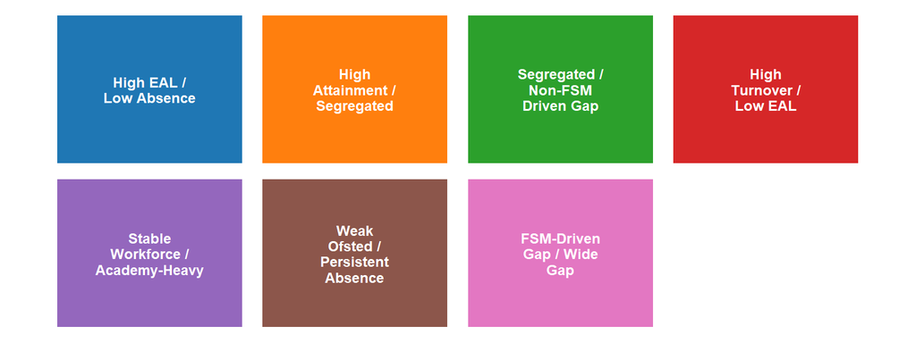

Figure 1

# 1 Attainment Indicators

The attainment indicators below correspond to **Section 3.1** of the methodology report. These are the primary measures of school performance at LA level, covering Attainment 8 scores, disadvantage gaps, gender differences, subject breakdowns, and Progress 8 value-added measures.

Each plot shows the distribution of a single variable across the 153 Local Authorities, broken out by cluster. The half-violin shows the density, the box plot shows the IQR and median, and the dots show individual LA values.

## 1.1 Overall Attainment 8

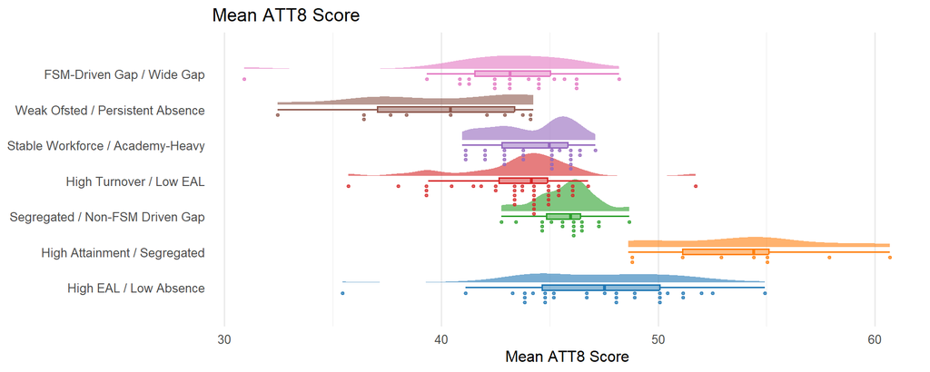

Figure 2: Mean ATT8 score — average Attainment 8 score across schools in each LA.

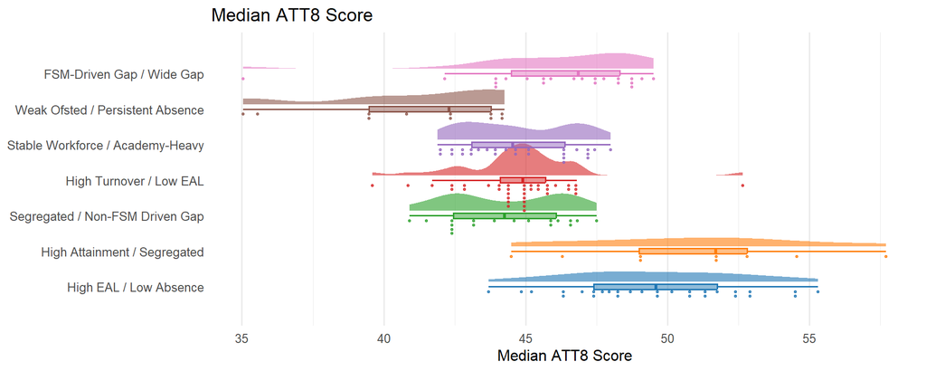

Figure 3: Median ATT8 score across schools in each LA.

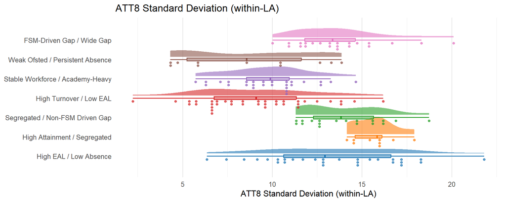

Figure 4: ATT8 standard deviation — within-LA spread of school performance.

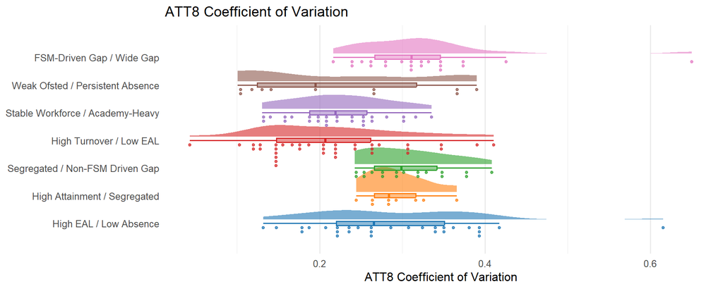

Figure 5: ATT8 coefficient of variation — relative spread (SD/mean).

## 1.2 Disadvantage Gap

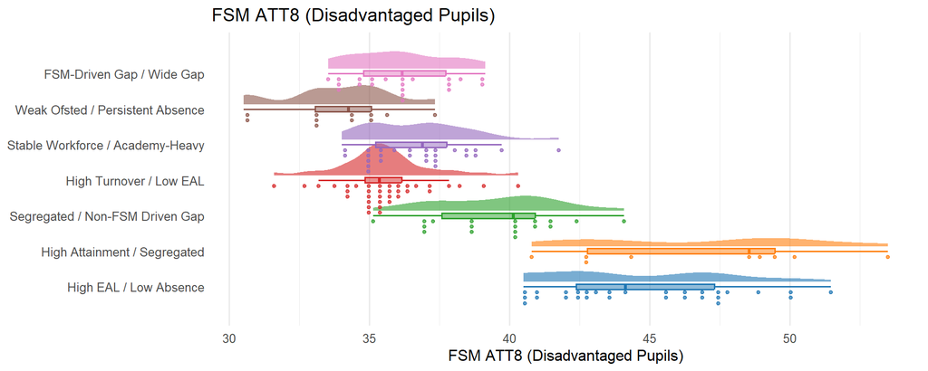

Figure 6: Mean ATT8 for disadvantaged (FSM6) pupils.

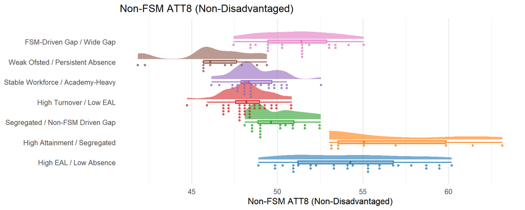

Figure 7: Mean ATT8 for non-disadvantaged pupils.

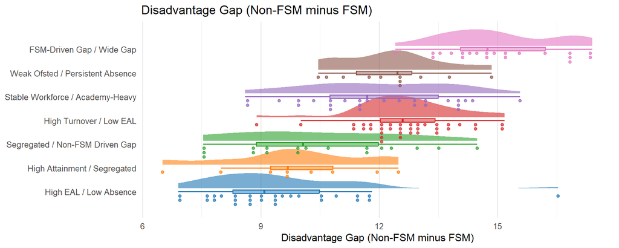

Figure 8: Disadvantage gap — mean difference between non-FSM and FSM ATT8 scores.

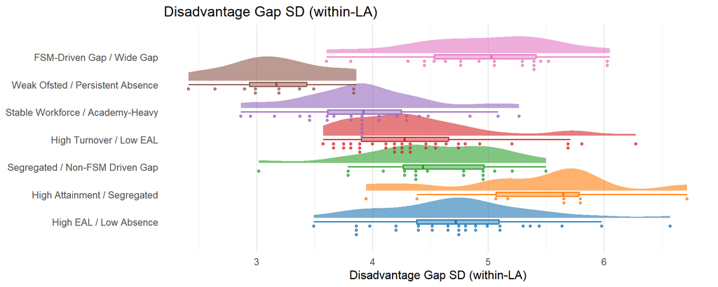

Figure 9: Within-LA variation in the disadvantage gap.

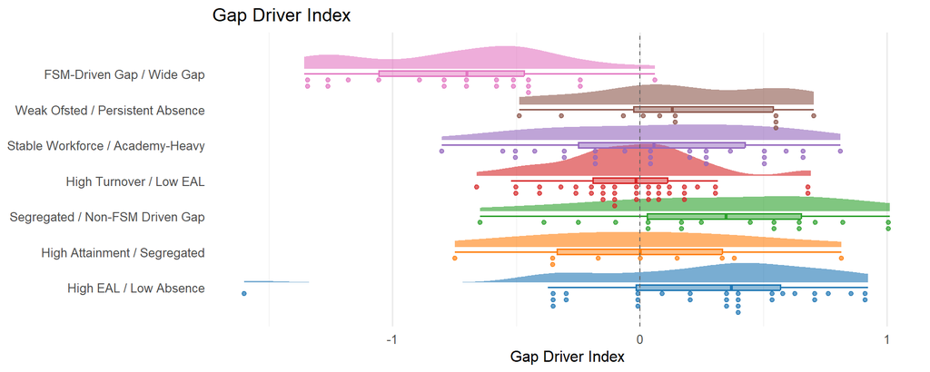

Figure 10: Gap driver index — negative = gap driven by low FSM attainment; positive = driven by high non-FSM attainment.

## 1.3 Gender & Subject Breakdown

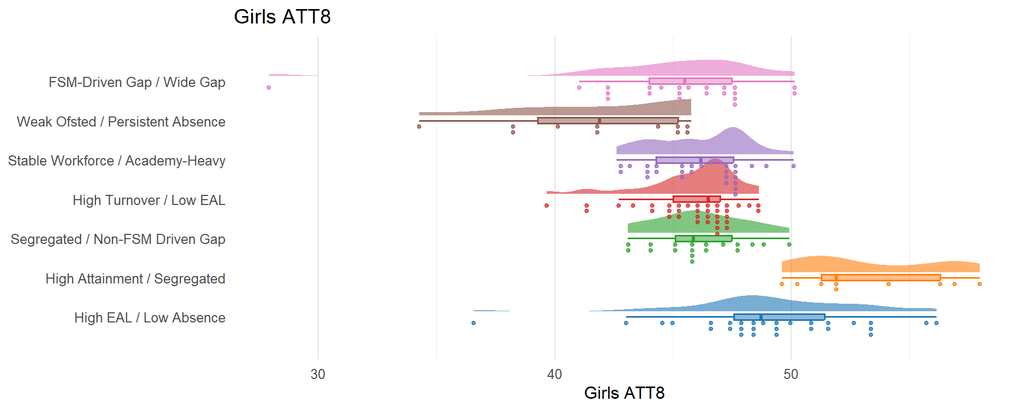

Figure 11: Mean ATT8 for girls.

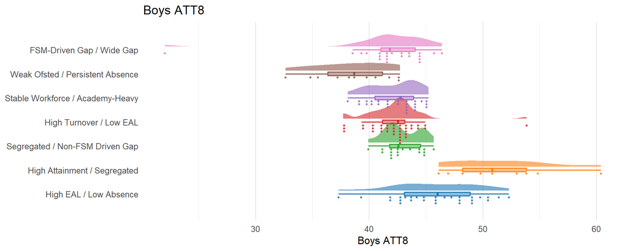

Figure 12: Mean ATT8 for boys.

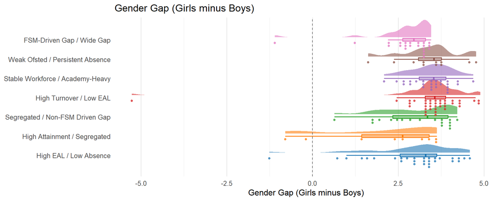

Figure 13: Gender gap in ATT8 (girls minus boys).

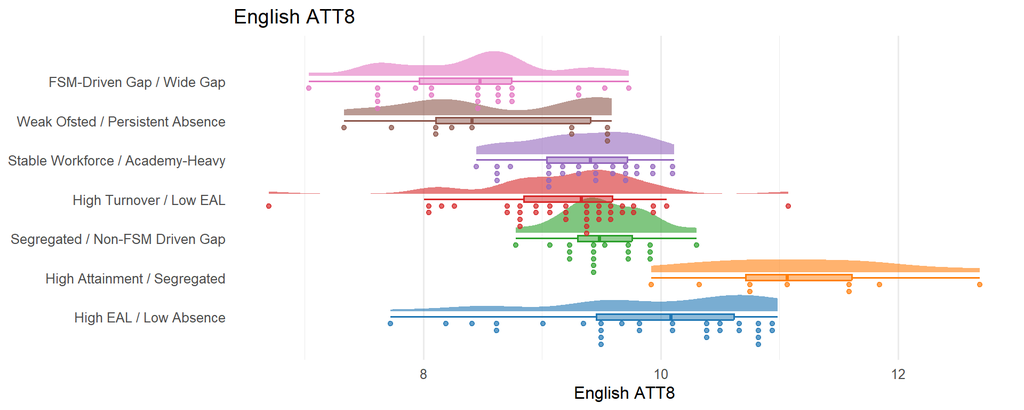

Figure 14: Mean ATT8 in the English element.

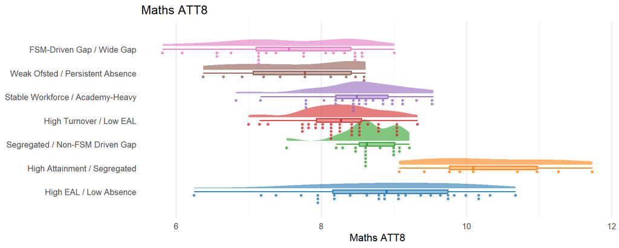

Figure 15: Mean ATT8 in the Maths element.

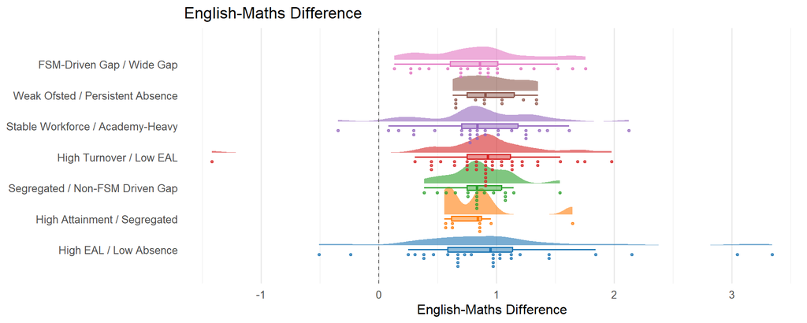

Figure 16: English minus Maths ATT8 — relative subject performance within LAs.

## 1.4 Progress 8

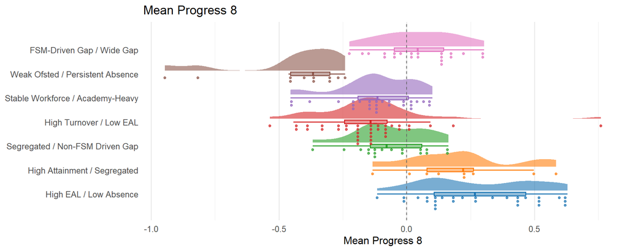

Figure 17: Mean Progress 8 — value-added relative to prior attainment. Zero = national average.

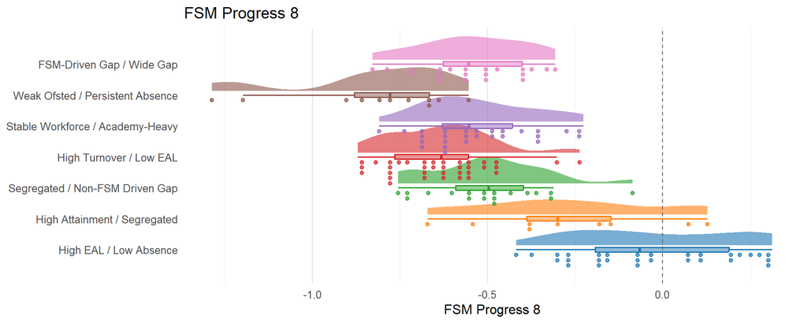

Figure 18: Progress 8 for disadvantaged (FSM) pupils.

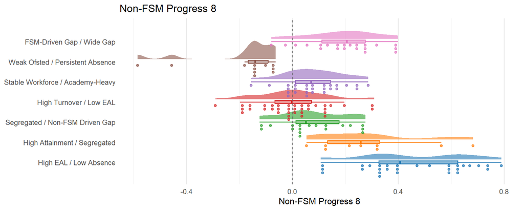

Figure 19: Progress 8 for non-disadvantaged pupils.

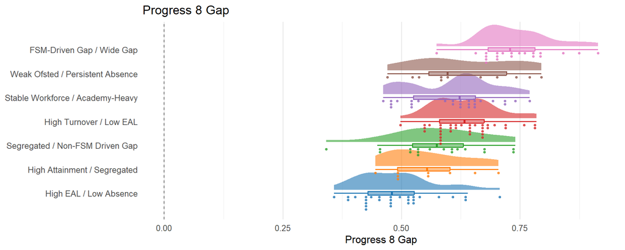

Figure 20: Gap in Progress 8 between non-FSM and FSM pupils.

## 1.5 Attainment Trends

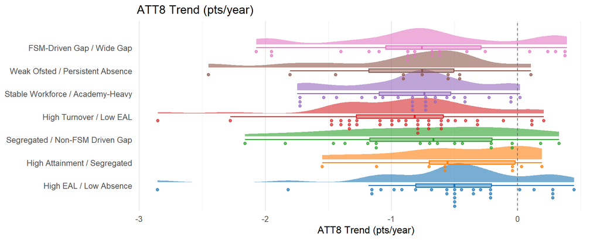

Figure 21: Annual change in mean ATT8 (points per year). Positive = improving.

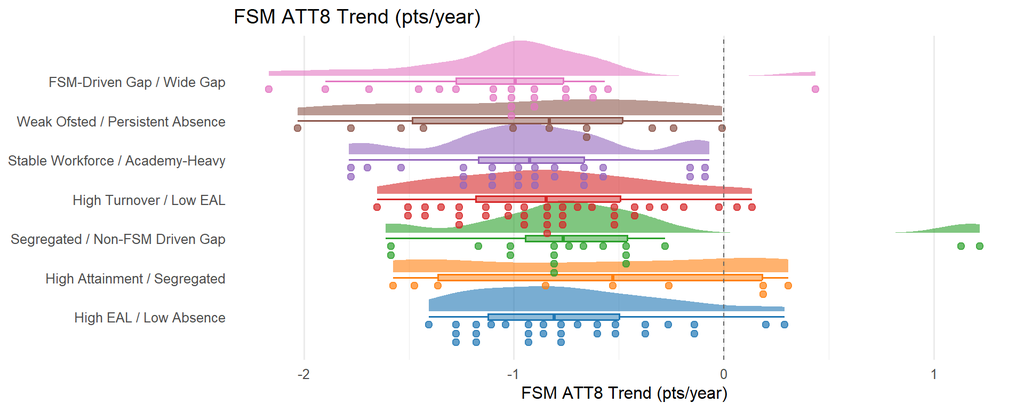

Figure 22: Annual ATT8 trend for disadvantaged pupils.

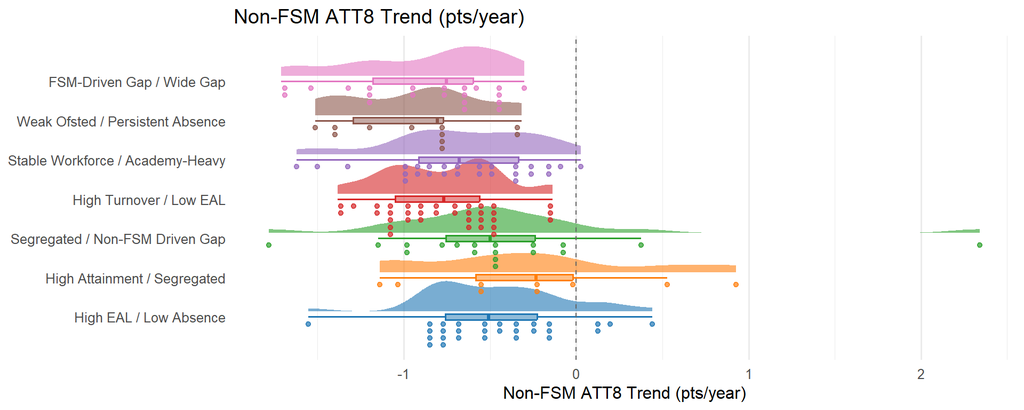

Figure 23: Annual ATT8 trend for non-disadvantaged pupils.

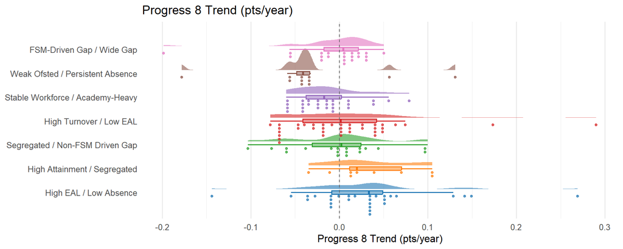

Figure 24: Annual trend in Progress 8.

## 1.6 Summary Statistics Table

Table 1: Summary statistics for all attainment indicators.

| var_label | N | Mean | SD | Min | Q25 | Median | Q75 | Max |
| --- | --- | --- | --- | --- | --- | --- | --- | --- |
| ATT8 CV | 153 | 0.26 | 0.09 | 0.04 | 0.20 | 0.26 | 0.32 | 0.65 |
| ATT8 SD | 153 | 11.62 | 3.72 | 2.24 | 9.11 | 11.63 | 14.31 | 21.81 |
| ATT8 Trend | 153 | -0.75 | 0.64 | -2.85 | -1.11 | -0.70 | -0.36 | 0.45 |
| Boys ATT8 | 153 | 43.22 | 4.24 | 22.04 | 41.21 | 42.82 | 44.77 | 60.41 |
| Disadvantage Gap | 151 | 11.79 | 2.43 | 6.51 | 9.96 | 12.02 | 13.47 | 17.40 |
| Eng-Maths Diff | 153 | 0.90 | 0.53 | -1.42 | 0.67 | 0.88 | 1.11 | 3.34 |
| English ATT8 | 153 | 9.35 | 0.95 | 6.70 | 8.75 | 9.41 | 9.78 | 12.69 |
| FSM ATT8 | 151 | 38.65 | 4.73 | 30.53 | 35.15 | 37.18 | 40.98 | 53.49 |
| FSM ATT8 Trend | 151 | -0.82 | 0.55 | -2.17 | -1.16 | -0.85 | -0.54 | 1.22 |
| FSM P8 | 151 | -0.46 | 0.30 | -1.29 | -0.67 | -0.52 | -0.31 | 0.31 |
| Gap Driver Index | 151 | 0.00 | 0.52 | -1.60 | -0.32 | 0.03 | 0.38 | 1.01 |
| Gap SD | 151 | 4.44 | 0.81 | 2.41 | 3.88 | 4.39 | 4.98 | 6.72 |
| Gender Gap | 153 | 3.10 | 1.24 | -5.27 | 2.77 | 3.36 | 3.72 | 4.89 |
| Girls ATT8 | 153 | 46.54 | 3.91 | 27.94 | 44.99 | 46.56 | 48.04 | 57.97 |
| Maths ATT8 | 153 | 8.45 | 0.98 | 5.82 | 7.93 | 8.48 | 9.01 | 11.73 |
| Mean ATT8 | 153 | 44.86 | 4.21 | 30.92 | 42.94 | 44.77 | 46.28 | 60.68 |
| Mean P8 | 152 | -0.02 | 0.28 | -0.95 | -0.18 | -0.05 | 0.12 | 0.76 |
| Median ATT8 | 153 | 45.89 | 3.67 | 35.05 | 43.90 | 45.50 | 47.55 | 57.70 |
| Non-FSM ATT8 | 151 | 50.44 | 3.62 | 41.86 | 48.19 | 49.47 | 51.94 | 63.14 |
| Non-FSM ATT8 Trend | 151 | -0.65 | 0.52 | -1.78 | -0.95 | -0.65 | -0.40 | 2.34 |
| Non-FSM P8 | 151 | 0.14 | 0.24 | -0.58 | -0.01 | 0.11 | 0.27 | 0.79 |
| P8 Gap | 151 | 0.60 | 0.11 | 0.34 | 0.52 | 0.61 | 0.68 | 0.91 |
| P8 Trend | 152 | 0.00 | 0.06 | -0.20 | -0.04 | 0.00 | 0.03 | 0.29 |

# 2 Interactive LA Variable Map

Select any of the **171** numeric variables in the LA indicators dataset to colour a choropleth map and view its distribution.

**NoteHow to use**

Use the **dropdown** on the map to choose any variable. The **choropleth map** updates automatically to show the spatial pattern of the selected variable across all 153 LAs. Hover over an LA to see its value; click for a popup with full details.

[interactive chart not shown]

Figure 25: Interactive choropleth map — use the dropdown to select a variable and explore spatial patterns across LAs.

### 2.0.1 Cluster Reference Map

[interactive chart not shown]

Figure 26: Reference map showing LA cluster assignments. Compare with the variable choropleth above to see how spatial patterns relate to cluster membership.

# 3 Correlation Matrix

The correlation matrix below shows pairwise Pearson correlations across all **123** variables that survived the filtering pipeline and entered the k-means clustering. Variables with >30% missing, near-zero variance, or |r| > 0.97 redundancy were already removed.

[interactive chart not shown]

Figure 27: Correlation heatmap of all clustering variables. Strong positive correlations in red, strong negative in blue.

Table 2: Mean absolute correlation between variable themes — shows which indicator domains are most strongly interrelated.

|  | Absence | Attainment | Ofsted | Other | Pupils | School Type | Segregation | Workforce |
| --- | --- | --- | --- | --- | --- | --- | --- | --- |
| Absence | 0.362 | 0.256 | 0.191 | 0.101 | 0.190 | 0.123 | 0.149 | 0.126 |
| Attainment | 0.256 | 0.317 | 0.226 | 0.109 | 0.205 | 0.097 | 0.132 | 0.125 |
| Ofsted | 0.191 | 0.226 | 0.457 | 0.133 | 0.122 | 0.103 | 0.070 | 0.099 |
| Other | 0.101 | 0.109 | 0.133 | 0.083 | 0.121 | 0.111 | 0.109 | 0.123 |
| Pupils | 0.190 | 0.205 | 0.122 | 0.121 | 0.197 | 0.115 | 0.163 | 0.151 |
| School Type | 0.123 | 0.097 | 0.103 | 0.111 | 0.115 | 0.135 | 0.095 | 0.111 |
| Segregation | 0.149 | 0.132 | 0.070 | 0.109 | 0.163 | 0.095 | 0.230 | 0.105 |
| Workforce | 0.126 | 0.125 | 0.099 | 0.123 | 0.151 | 0.111 | 0.105 | 0.185 |

# 4 Full Cluster Z-Score Profiles

The radar charts in the methodology report show cluster profiles across 10 key variables. This section provides a **comprehensive view of all 123 variables** that went into the clustering, displaying the mean z-score for each cluster. This reveals which variables most strongly differentiate the clusters and which are relatively uniform.

**TipReading these charts**

Each bar represents a cluster’s mean z-score on that variable. Values above zero indicate the cluster is above the England average; below zero means below average. Longer bars mean stronger differentiation. Variables are grouped by thematic domain.

## 4.1 Interactive Z-Score Explorer

[interactive chart not shown]

Figure 28: Interactive z-score bar chart — hover over bars for exact values. Use the legend to toggle clusters on/off.

## 4.2 Most Differentiating Variables

Which variables show the greatest separation between clusters? Below are the top 30 variables ranked by the **range of cluster-mean z-scores** (i.e., the difference between the highest and lowest cluster averages).

Table 3: Top 30 most differentiating variables — ranked by the range of mean z-scores across clusters.

| Variable | Theme | Z-range | Max z | Min z | Highest cluster | Lowest cluster |
| --- | --- | --- | --- | --- | --- | --- |
| att8_p75 | 1. Attainment & Progress | 3.864 | 2.622 | -1.242 | High Attainment / Segregated | Weak Ofsted / Persistent Absence |
| pct_prior_hi_mean | 2. Pupil Composition | 3.686 | 2.807 | -0.879 | High Attainment / Segregated | Weak Ofsted / Persistent Absence |
| att8_fsm_sd | 1. Attainment & Progress | 3.371 | 2.693 | -0.679 | High Attainment / Segregated | Weak Ofsted / Persistent Absence |
| pct_prior_hi_sd | 2. Pupil Composition | 3.330 | 2.618 | -0.711 | High Attainment / Segregated | Weak Ofsted / Persistent Absence |
| att8_mean | 1. Attainment & Progress | 3.320 | 2.138 | -1.182 | High Attainment / Segregated | Weak Ofsted / Persistent Absence |
| att8_nfsm_sd | 1. Attainment & Progress | 3.202 | 2.340 | -0.862 | High Attainment / Segregated | Weak Ofsted / Persistent Absence |
| att8_boys_mean | 1. Attainment & Progress | 3.060 | 1.970 | -1.090 | High Attainment / Segregated | Weak Ofsted / Persistent Absence |
| abs_persist_cv | 3. Absence | 2.942 | 2.061 | -0.881 | High Attainment / Segregated | Weak Ofsted / Persistent Absence |
| att8_girls_mean | 1. Attainment & Progress | 2.942 | 1.745 | -1.197 | High Attainment / Segregated | Weak Ofsted / Persistent Absence |
| att8_nfsm_mean | 1. Attainment & Progress | 2.918 | 1.732 | -1.186 | High Attainment / Segregated | Weak Ofsted / Persistent Absence |
| pct_fsm_cv | 2. Pupil Composition | 2.917 | 1.890 | -1.027 | High Attainment / Segregated | Weak Ofsted / Persistent Absence |
| att8_eng_mean | 1. Attainment & Progress | 2.891 | 1.918 | -0.974 | High Attainment / Segregated | FSM-Driven Gap / Wide Gap |
| att8_mat_mean | 1. Attainment & Progress | 2.803 | 1.910 | -0.893 | High Attainment / Segregated | FSM-Driven Gap / Wide Gap |
| att8_max | 1. Attainment & Progress | 2.770 | 1.475 | -1.295 | High Attainment / Segregated | Weak Ofsted / Persistent Absence |
| att8_fsm_cv | 1. Attainment & Progress | 2.756 | 2.240 | -0.516 | High Attainment / Segregated | High Turnover / Low EAL |
| att8_fsm_mean | 1. Attainment & Progress | 2.754 | 1.739 | -1.015 | High Attainment / Segregated | Weak Ofsted / Persistent Absence |
| p8_nfsm_mean | 1. Attainment & Progress | 2.746 | 1.337 | -1.409 | High EAL / Low Absence | Weak Ofsted / Persistent Absence |
| att8_gap_sd | 1. Attainment & Progress | 2.712 | 1.130 | -1.582 | High Attainment / Segregated | Weak Ofsted / Persistent Absence |
| p8_fsm_mean | 1. Attainment & Progress | 2.682 | 1.457 | -1.225 | High EAL / Low Absence | Weak Ofsted / Persistent Absence |
| att8_median | 1. Attainment & Progress | 2.674 | 1.341 | -1.333 | High Attainment / Segregated | Weak Ofsted / Persistent Absence |
| att8_iqr | 1. Attainment & Progress | 2.672 | 1.917 | -0.756 | High Attainment / Segregated | Weak Ofsted / Persistent Absence |
| p8_mean | 1. Attainment & Progress | 2.668 | 1.124 | -1.545 | High EAL / Low Absence | Weak Ofsted / Persistent Absence |
| gorard_mean | 5. Segregation | 2.664 | 1.859 | -0.805 | High Attainment / Segregated | Weak Ofsted / Persistent Absence |
| p8_median | 1. Attainment & Progress | 2.576 | 1.086 | -1.489 | High EAL / Low Absence | Weak Ofsted / Persistent Absence |
| pct_prior_lo_mean | 2. Pupil Composition | 2.574 | 0.664 | -1.910 | Weak Ofsted / Persistent Absence | High Attainment / Segregated |
| abs_persist_mean | 3. Absence | 2.541 | 1.323 | -1.219 | Weak Ofsted / Persistent Absence | High Attainment / Segregated |
| att8_fsm_median | 1. Attainment & Progress | 2.534 | 1.576 | -0.959 | High EAL / Low Absence | Weak Ofsted / Persistent Absence |
| abs_persist_median | 3. Absence | 2.460 | 1.323 | -1.137 | Weak Ofsted / Persistent Absence | High Attainment / Segregated |
| fte_ta_to_teacher_ratio | 7. Workforce | 2.438 | 1.343 | -1.095 | Weak Ofsted / Persistent Absence | High Attainment / Segregated |
| att8_nfsm_median | 1. Attainment & Progress | 2.414 | 1.297 | -1.117 | High EAL / Low Absence | Weak Ofsted / Persistent Absence |

## 4.3 Cluster Heatmap

An alternative view — a heatmap of cluster-mean z-scores across all variables, with variables ordered by theme and within-theme by differentiating power.

[interactive chart not shown]

Figure 29: Heatmap of cluster-mean z-scores. Red = above England average, blue = below. Variables ordered by theme and differentiating power.

# 5 Appendix: Variable Inventory

Complete list of the **123** variables that passed through the filtering pipeline and entered the k-means clustering.

Table 4: All variables used in clustering, with theme assignment, missingness, and summary statistics.

| Variable | Theme | N non-missing | Mean | SD | Min | Max |
| --- | --- | --- | --- | --- | --- | --- |
| **Absence** |  |  |  |  |  |  |
| abs_att8_cor | Absence | 152 | -0.695 | 0.140 | -0.966 | -0.243 |
| abs_overall_cv | Absence | 152 | 0.249 | 0.063 | 0.049 | 0.430 |
| abs_overall_mean | Absence | 152 | 8.891 | 1.117 | 6.628 | 11.802 |
| abs_overall_median | Absence | 152 | 8.740 | 1.127 | 6.500 | 12.083 |
| abs_overall_sd | Absence | 152 | 2.217 | 0.629 | 0.327 | 3.872 |
| abs_persist_cv | Absence | 152 | 0.318 | 0.078 | 0.150 | 0.560 |
| abs_persist_mean | Absence | 152 | 25.911 | 3.516 | 15.812 | 36.544 |
| abs_persist_median | Absence | 152 | 25.555 | 3.646 | 15.150 | 36.840 |
| abs_persist_sd | Absence | 152 | 8.140 | 1.832 | 3.611 | 12.955 |
| abs_persist_to_overall_ratio | Absence | 152 | 2.861 | 0.128 | 2.371 | 3.106 |
| abs_persist_trend | Absence | 152 | -1.798 | 0.838 | -4.097 | 2.434 |
| abs_trend_slope | Absence | 152 | -0.271 | 0.196 | -0.923 | 0.283 |
| **Attainment** |  |  |  |  |  |  |
| att8_boys_mean | Attainment | 153 | 43.216 | 4.241 | 22.037 | 60.407 |
| att8_cv | Attainment | 153 | 0.262 | 0.092 | 0.043 | 0.650 |
| att8_eng_mat_diff | Attainment | 153 | 0.902 | 0.533 | -1.416 | 3.344 |
| att8_eng_mean | Attainment | 153 | 9.350 | 0.948 | 6.699 | 12.687 |
| att8_eng_sd | Attainment | 153 | 2.988 | 1.098 | 0.670 | 6.599 |
| att8_fsm_cv | Attainment | 151 | 0.192 | 0.067 | 0.075 | 0.384 |
| att8_fsm_mean | Attainment | 151 | 38.649 | 4.727 | 30.526 | 53.491 |
| att8_fsm_median | Attainment | 151 | 37.590 | 4.279 | 29.900 | 51.500 |
| att8_fsm_sd | Attainment | 151 | 7.488 | 3.165 | 2.905 | 18.238 |
| att8_fsm_trend_slope | Attainment | 151 | -0.824 | 0.552 | -2.166 | 1.219 |
| att8_gap_mean | Attainment | 151 | 11.786 | 2.427 | 6.510 | 17.402 |
| att8_gap_sd | Attainment | 151 | 4.445 | 0.810 | 2.414 | 6.716 |
| att8_gender_gap | Attainment | 153 | 3.102 | 1.238 | -5.267 | 4.894 |
| att8_girls_mean | Attainment | 153 | 46.544 | 3.905 | 27.938 | 57.966 |
| att8_iqr | Attainment | 153 | 12.792 | 6.165 | 1.425 | 38.325 |
| att8_mat_mean | Attainment | 153 | 8.448 | 0.984 | 5.817 | 11.733 |

[output cut: 101 more lines]

[UCL Centre for Advanced Spatial Analysis](https://www.ucl.ac.uk/bartlett/casa) · School Attainment Tool